# Political harassment is perceived as severe, unacceptable behavior by most citizens

**Søren Damsbo-Svendsen**

Karina Kosiara-Pedersen

November 19, 2025

## Motivation

- Common conception:
  - **political violence is increasingly accepted**
  - harassment against politicians no longer perceived as serious problem
- Limited empirical evidence – with broad scope
  - e.g., many expressions, not only online, different contexts
- RQ: How severe is harassment of politicians perceived to be by citizens,  
  and who finds it less severe?
- New survey data — shared with **experimental study:**

## Experiment

> ‘Raising awareness of harassment against politicians: Experimental evidence of disengagement among likely future candidates’

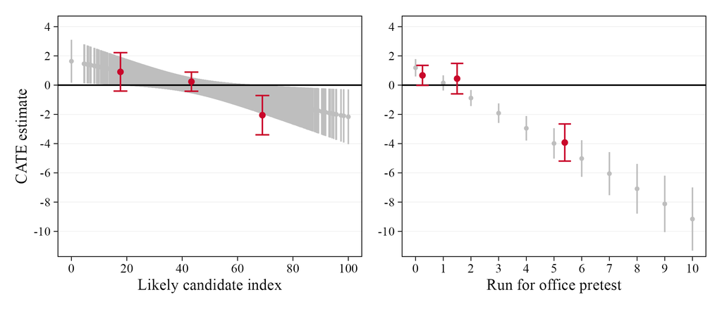

## Status

- Second-ish draft
  - empirics quite far
  - theory quite undeveloped
- Updated framing after DIPAS workshop in Sept:
  - push back against conception that acceptance of violence is growing/high
  - emphasize groups with higher acceptance

## Design

- Large citizen **survey:** n = 8,899
  - DK: n = 5,008 (YouGov)
  - DE = 1,519, UK = 1,515, FR = 857 (Prolific)
- **Stimuli:** 55 *true stories* of (Danish) politicians’ experiences with harassment
  - source: 2021 municipal election candidate survey (n = 3,986)
  - hand-selected and edited (~ 24 words each)
- **Task:** read + judge 5 random harassment stories
- **Outcome**: perceived severity index
  - => 43,460 severity judgments of 55 diverse harassment stories

## Harassment story examples

> ‘I have experienced coming home to several of the trees in my front yard having been cut down.’

> ‘I have experienced that my politician page on Facebook was shared by a fake profile with an encouragement to comment negatively on all my posts.’

> ‘I have received death threats from unknown senders directed at both my little brothers and my own children.’

> ‘There was a citizen who drove around in a car and measured how high my - and only my - posters were placed from the ground. He then reported me to the police for posters that were placed too low.’

## How the stories are presented

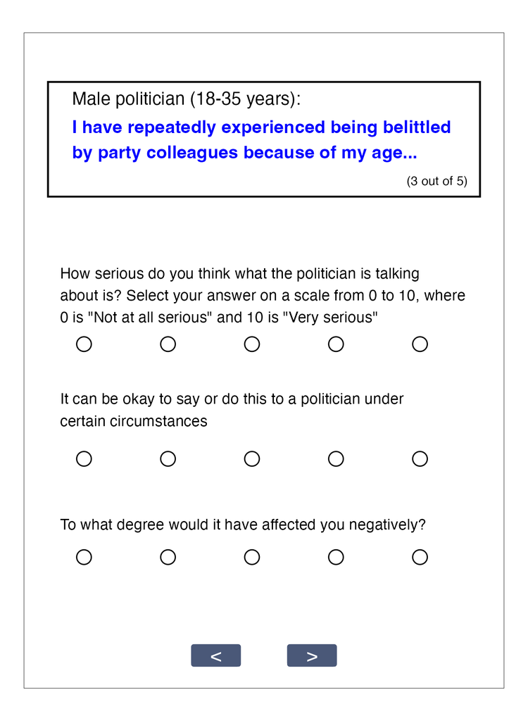

- 1 of 4 **politician** *gender-age* categories (randomized)
- Story
- **Judgment** on three dimensions:
  - A Seriousness
  - B Justifiableness
  - C Harmfulness

## Perceived severity

- **Outcome:** judgments combined into a **perceived severity index**
  - => effectively, respondents rate each story’s severity from 0 to 100
- **Predictors** – or ‘gaps’ of interest:
  1. respondent gender and age
  2. politician gender and age
  3. gender-age affinity (shared identity)
  4. political ideology
  5. harassment type
- **Main analysis:** OLS regression of (mean) predicted severity by each predictor/group

# Results

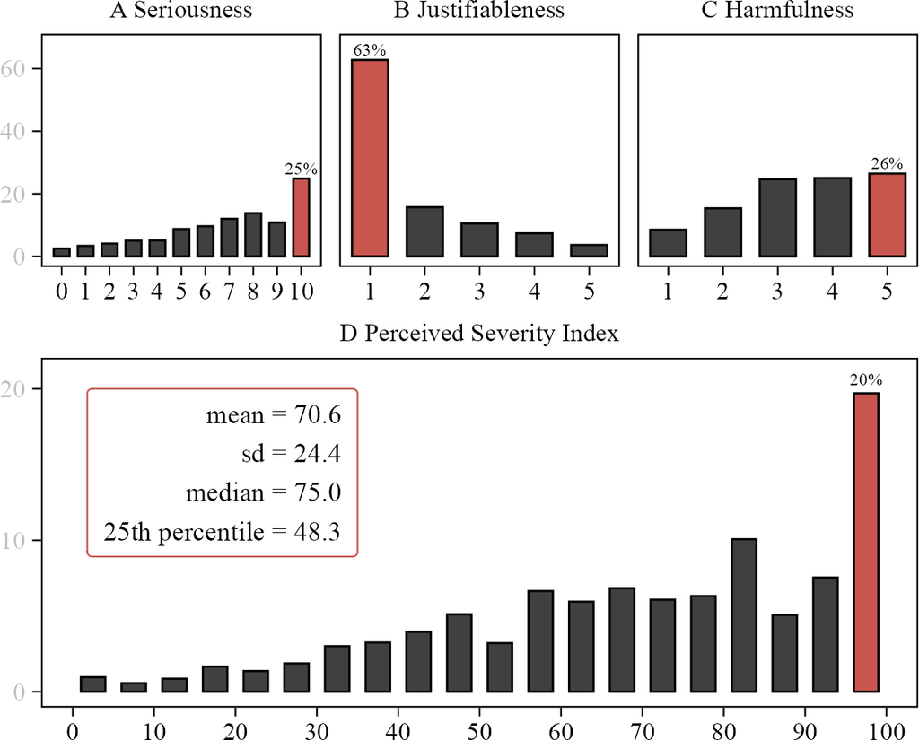

## Gender and age

**Political harassment is perceived as *less severe …***

- H1: by men
- H2: by older people

## Gender and age

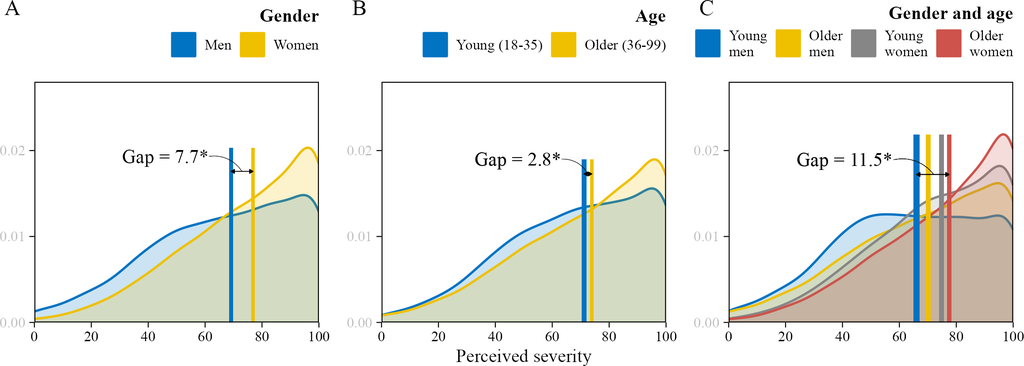

## Gender and age

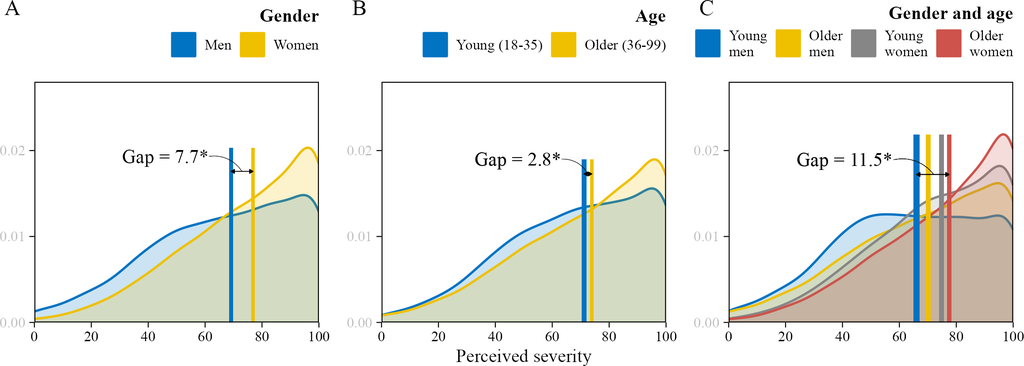

- Lower for **men** (H1 +)
- Lower for **young** people (H2 -)
- Lowest among **young men**

## Politicians’ gender and age

**Political harassment is perceived as *less severe …***

- H3: when the targeted politician is a man
- H4: when the targeted politician is an older person
- H5: by people who belong to a different (gender-age) group than the targeted politician

## Politicians’ gender and age

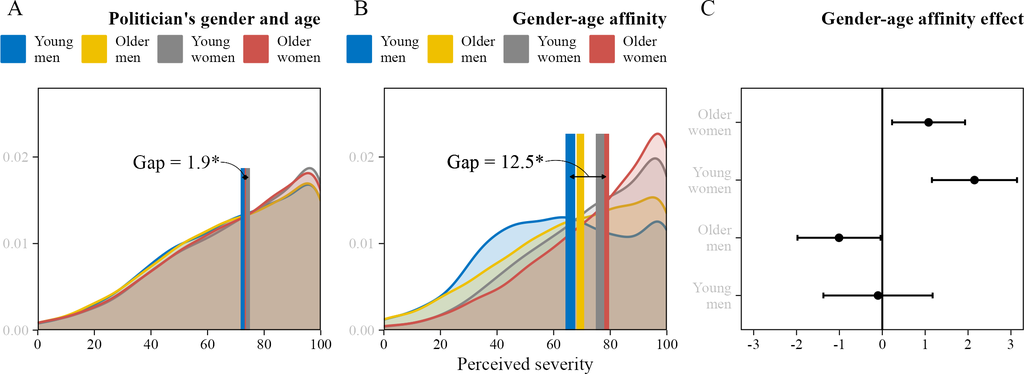

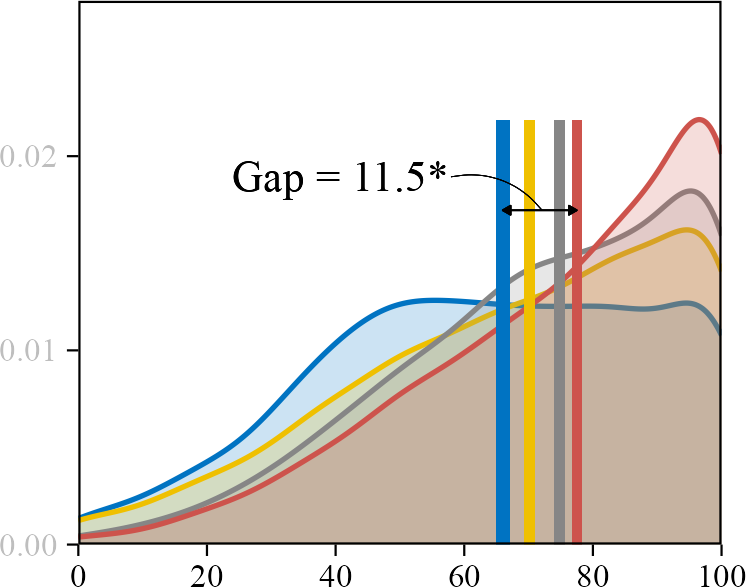

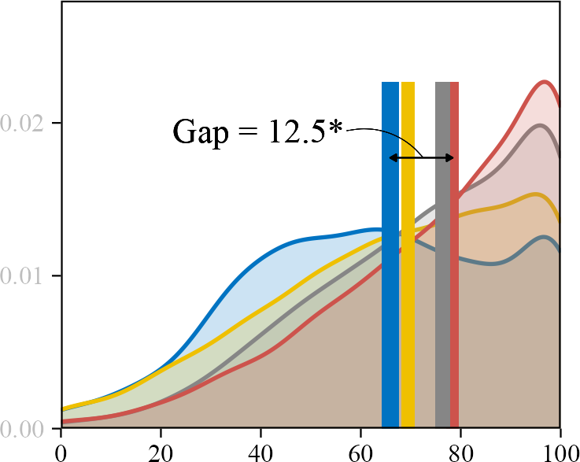

Full sample

Affinity subset  
(~25%)

## Politicians’ gender and age

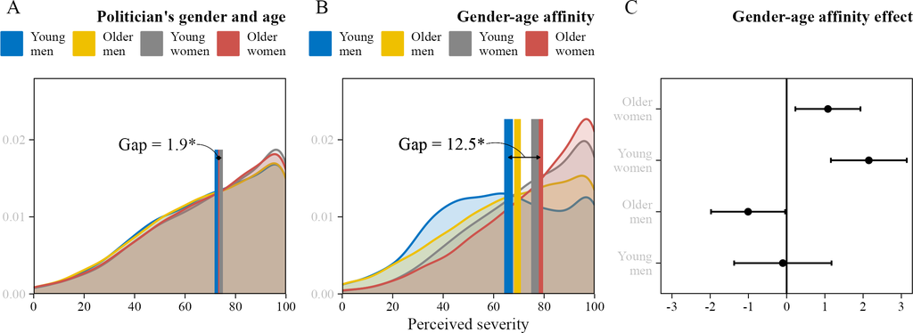

- **Women politician:**  
  slightly more severe  
  (*young* women, H3 +)
- **Young politician:**  
  no gap (H4 -)
- **Gender-age affinity:**
  - worse for women (H5 +)
  - less for older men (H5 -)
  - driven by perceptions for  
    women politicians (H3)

## Political ideology

**Political harassment is perceived as *less severe …***

- H6: by people who identify as ideologically right-leaning (27%)
- H7: by people who are generally more tolerant of harassment in politics (18%)
- H8: by people who are dissatisfied with democracy (31%)
  - **viscous cycle:**
    - *dissatisfaction* → low severity perceptions → more harassment → degraded representation → *dissatisfaction*

## Political ideology

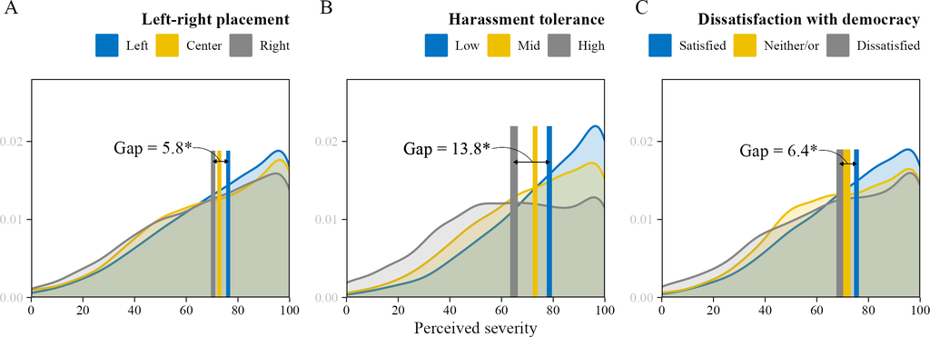

## Political ideology

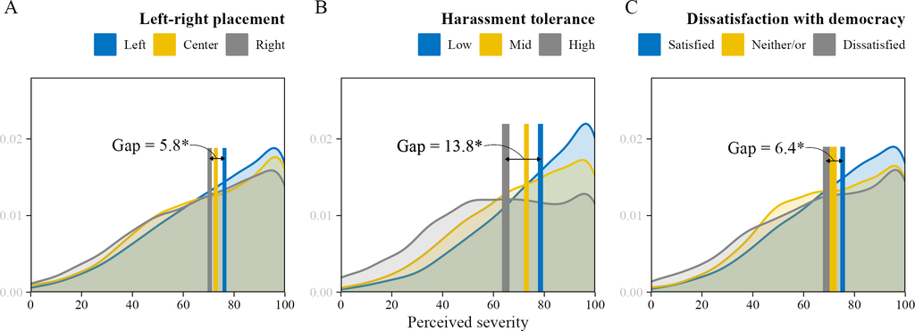

Lower perceived severity if the respondent:

- leans right (H6 +)
- generally tolerates harassment (H7 +)
- is dissatisfied with democracy (H8 +)

## Harassment type

- Explorative analysis of five harassment types (vs. rest)
  1. **physical** harassment
  2. **threats** of violence
  3. **property** damage
  4. **sexual** harassment
  5. **social media** (online arena)
- Total and by:
  - gender and age
  - left-right placement

# Conclusion

- We asked **how citizens perceive the severity of harassment** against politicians
- To address the **broader question:** Is political violence/harassment becoming more accepted?
- We designed a large survey with real(istic) stories of harassment
- **Results:** high severity perceptions overall → rejection of violence/harassment
  - important, sometimes large **perception gaps**
  - some **expected** (e.g., gender, ideology, threats)
  - others **unexpected** (e.g., age, gender-age affinity, sexual)
- Should pay attention to **groups with low perceptions**  
  (e.g., young men, the right, democratically dissatisfied)

# Thank you

# Extra

## Flowchart

[figure not shown]